# Throw Them All in One Bag

Polarised Perception of Homogeneous Out-Party Camps

Author

Felix Grünewald

Abstract

Polarisation in multi-party systems is a complex matter. Compared to the classic but rare two-party case in the US, there are more points of reference between which ideological differences and affect can occur. Recent approaches considered groups of favoured and unfavoured parties, but continue to treat all parties individually. I argue that a perception of political camps, consisting of multiple ideologically close parties, plays a crucial role in how citizens perceive the ideological positions of parties. Applying the concept of outgroup homogeneity from psychology to party politics, I assume that opposing parties are perceived as ideologically more homogenous than those on one’s own side of the political spectrum. Using data from the fifth wave of the Comparative Studies of Election Surveys, I analyse how the perception of homeogenous party camps depends on party affiliation and affect. Results show that the outcamp is seen as less differentiated with increasingly negative feeling towards it. I conclude that the concept of outgroup homogeneity has potential to help us understand the mechanisms of polarisation generally, and in multi-party systems specifically.

# 1 Introduction

Not liking a political opponent would hardly pose a threat to democratic stability. In fact, according to social cohesion literature, disagreement is part of a healthy societal discourse, whereby cross-cutting coalitions overlapping between interest groups tie a society together (Mason, 2016). But what if the disagreement and dislike towards some are extrapolated to an entire outgroup of political opponents? Political opponents who are theoretically and emotionally closer to the ingroup would be associated, or even equated with those who are furthest away and most disliked. By making coalitions and compromises between parties and political groups increasingly unthinkable, I argue that it is a lack of differentiation between members of the political outgroup that acts as a major co-driver of affective polarisation.

To make this argument, I build on a concept from the field of psychology, outgroup homogeneity (Boldry et al., 2007; Ostrom & Sedikides, 1992). Socially formed groups have been shown in many cases to perceive less variance in traits and attitudes in their respective outgroups. The affective polarisation literature is at its core based on theories of group identity and stereotyping (Iyengar et al., 2019; Wagner & Eberl, 2022). New strains of research argue that negative affect is driven by global-level sorting processes in which citizens divide into increasingly distinct political camps (Törnberg, 2022). The perception of a homogeneous outgroup fits neatly into this theory and could explain the perception of these political camps at the individual level.

I expect an outgroup homogeneity effect for the political outgroup, i.e., a lower perceived variance for the political outgroup than for the ingroup. Furthermore, I expect that stronger dislike of the outgroup is associated with a stronger perception of homogeneity. By testing these hypotheses, I believe that I will be able to provide clearer insights into how political identities are formed, how they can threaten democratic coalitions, and how they can drive negative affect.

I test this effect in Western European democracies using data from the fifth wave of the CSES. The context of multi-party systems, where political ingroups and outgroups are less well defined and span multiple parties, is arguably a more difficult test of these hypotheses. However, I argue that the perception of homogeneity in political outgroups is a crucial factor for understanding how a political outgroup is constructed in a multi-party system. I base my analysis on the premise of two camps of political parties, on the left and right of the political spectrum, and expect that the outcamp will be perceived as less differentiated and more equated with its most extreme members than the incamp.

I find a significant difference between in- and outgroup variance in all but one of the nine sample countries, as well as a positive relationship between variance perception and favorability of a political camp. Even though these results rely on the definition of party camps, the concept of outgroup homogeneity shows promise to explain processes of polarisation.

# 2 Literature Review

The literature distinguishes between two main forms of political polarisation: ideological and affective polarisation. Ideological polarisation, described in Sartori’s (2005) seminal work as a “centrifugal” tendency of a party system, can be broadly characterised as a growing distance between political opinions. This phenomenon has been studied at different levels: between voters (Abramowitz & Saunders, 2008), between political parties (Dassonneville & Çakır, 2021) and for the perception of party positions (Dalton, 2021).

While ideological polarisation stands as the more classical view in the literature, more recent research has started to look at the affective component of political division (Iyengar et al., 2012). The term affective polarisation has been applied in many different contexts, but generally, it can be defined as the “tendency […] to dislike and distrust” the political opponent (Druckman & Levendusky, 2019). While this is intuitively related to ideological polarisation, the two phenomena are not strictly the same, but rather weakly connected (Gidron et al., 2018; Harteveld, 2021b; Reiljan, 2020). Ideological polarisation has often been described as a fairly neutral phenomenon, or even as a net positive, increasing turnout (Béjar et al., 2020). With regard to affective polarisation, on the other hand, experts are more apprehensive. While it, too, has been shown to make elections more meaningful (Wessels & Schmitt, 2008) and increase turnout (Harteveld & Wagner, 2023), dislike towards the political opponent was also found to motivate opinion formation (away from being a function of one’s own values, but a distinction from the opposition) (Druckman et al., 2021; Guber, 2013), reduce the willingness to socialize with outpartisans (Iyengar & Westwood, 2015) and in extreme forms even increase the acceptance of violence towards them (Berntzen et al., 2022).

Negative bias and prejudice towards the political opposition are common themes in the literature on affective polarisation (Hobolt et al., 2021; Iyengar et al., 2019; Wagner & Eberl, 2022). This has been explained by political parties constituting increasingly strong group identities (Iyengar et al., 2019; Iyengar & Westwood, 2015). Such considerations go back to Social Identity Theory (Billig & Tajfel, 1973), according to which citizens need to categorize themselves and others into different social groups in order to construct a self-identity (see Hornsey, 2008). Political in- and outgroups are constructed to define one’s own position in the system. Constructing these groups, however, necessarily goes along with loss of detail and accuracy. Citizens have to make assumptions about the members of such groups, as it is impossible to see the full picture. Or, as Ahler & Sood (2018, p. 965) put it: “We cannot literally meet the party”.

Thus, it is no wonder that the perception of parties can be skewed. For one, the share of traits in parties can be heavily misestimated: For example, Americans believe that 32% of Democrats identify as LGB, when in reality this share is 6%. This misperception is stronger among outparty members, in this case Republicans (Ahler & Sood, 2018).[^1]. Such a connection between political proximity, favorability and (mis)perception has been confirmed in other contexts (Abeles et al., 2019; Dahlberg, 2013; Krosnick & Brannon, 1993). More politically aligned (with their own party) partisans furthermore perceive a larger gap to their political opponents than those who disagree with their inparty’s positions (Abeles et al., 2019).

The perception of trait prevalence therefore seems to be strongly related to partisanship. The question remains whether this perception relates to the whole group or just some subgroups. Perceiving just a subgroup of the political opposition to possess negative traits should be relatively inconsequential. However, if these traits were to be inferred to the outgroup as a whole, they could hamper relationships with unrelated outgroup members and make inter-group coalitions more difficult.

The concept of outgroup homogeneity is a well established one in psychology (for a review, see Boldry et al., 2007; Ostrom & Sedikides, 1992). It describes a “general cognitive bias toward perceiving the membership of other groups as less variable than the membership of one’s own group” (Ackerman et al., 2006). Homogeneity perception thereby is strongest for group-specific stereotypes but is not tied to certain traits.[^2] There are examples of such an effect to be found in a range of different contexts, including between ethnic groups in the U.S. (Ackerman et al., 2006) or between nationalities (e.g., between South-African and American Whites (Bartsch et al., 1997)). It is dependent on several group factors, such as size, social position or objective variability of the groups (Rubin & Badea, 2012). Replicating this effect in minimal experimental settings, i.e. with minimized contextual factors affecting the group perception, yielded inconclusive results (Boldry et al., 2007). It can therefore be assumed that the effect is socially developed and ‘learned’.

Following the ideas on party memberships as group identities, it appears intuitive to apply this concept to party contexts and, yet, this has rarely been done, and as of yet never in cross-national research. Wilson et al. (2020) discuss a possible “polarisation feedback loop”, in which the worst impressions would be inferred to the whole outgroup, thereby increasing the (false) perception of polarisation which in turn increases actual polarisation. Kelly (1989) applies the idea to Labour and Conservatives in the UK and can show that the opposition party is perceived as more homogenous when political self-identity is stronger. Such research can serve here to highlight the relevance of this phenomenon but they do not look at the actual relationships between political identification, outgroup homogeneity perception and negative affect. With this paper, I aim to establish a homogenous, i.e., less differentiated perception of the opponent as an important factor for affective polarisation levels.

# 3 Theory

Most research on affective polarisation has been conducted in the United States. While this is an important case in many ways, its two-party system makes inferences to other democracies difficult. Recent research has also given reason to give a closer look to affective polarisation in multi-party systems (Reiljan, 2020; Wagner, 2021). Here, however, the definitions and operationalisations become much blurrier than in a mostly two-party system like the U.S. As there are not just two clearly defined political groups, which party, politicians and voters are seen as the political opponent, both ideologically and emotionally? I follow other literature (Bantel, 2023; Wagner, 2021) on the argument that group identification in multi-party systems is based on the perception of political camps that include a range of parties, rather than clear in- and outparties.

The idea of party camps is not new (see Wagner, 2021). We already know that multi-party systems generally show lower self-identification with individual parties (Huddy et al., 2018). Recent research has therefore argued that identification with, and affect towards parties works not by a dichotomous distinction, but gradually (Harteveld, 2021a). It is possible to feel positively and negatively about multiple parties. Wagner (2021) consequently defines affective polarisation in multi-party systems as “the extent to which politics is seen as divided into two distinct camps, each of which may consist of one or more parties”. I follow this argument but want to take a closer look at the perception of such camps (or: groups of parties). Nonetheless, all further theory builds on the assumption that parties, generally, are perceived in certain clusters.

**Premise:** Political parties in multi-party systems are perceived in two distinct camps.

Of course, the perception of such camps will vary, not only by country, but also by partisanship. For example, a classic trademark of populist parties would be to perceive all “establishment” parties as one group of parties, while these parties might draw the lines between camps at completely different points. Testing homogeneity perceptions in a multi-party context is arguably a harder test, compared to asking about members of specific parties. However, if such effects can be found in this context, outgroup homogeneity could not only be assumed to be a general driver of affective polarisation, but an important puzzle piece in the process of polarisation in multi-party systems too.

The concept of outgroup homogeneity and affective polarisation were explained above, from the known literature we can draw several conclusions to build theory on. For one, homogeneity perception occurs between social groups (Ostrom & Sedikides, 1992), therefore we can assume such processes to also occur between political groups. Political partisanship in modern democracies has (at least in the US) been shown to make up an important part of identity formation (Iyengar et al., 2019), with the creation of in- and outgroups as a consequence. In multi-party systems, on the other hand, political identification occurs on a gradual scale rather than a dichotomous distinction (Harteveld, 2021a). Therefore, under the premise that parties are perceived as members of political camps, we can consequently expect an effect of outgroup homogeneity to occur between such camps:

**H1.1**: Parties in opposing party camps are perceived as ideologically closer to each other than those in the allied camp.

Perception of homogeneity would be less significant, if the group in question agrees with such a perception. A camp of political parties could also be “objectively” homogenous, something that for individual parties has been shown to affect positional perceptions (Imre, 2023). To further specify the assumptions, I therefore also hypothesize that the outcamp is perceived as more homogenous than members of that camp perceive it themselves.

**H1.2**: Parties in a party camp are perceived as ideologically closer to each other by members of the opposing party camp than by members of their allied camp.

These hypotheses are exclusively directed at the outgroup (although this of course always includes comparisons to the ingroup). Other research on the outgroup homogeneity effect has also found ingroup homogeneity perceptions under certain circumstances (Brewer, 1993; Kelly, 1989). For this introductory paper, I want to focus on just the outgroup, under the assumption that it is its perception that mainly drives attitudes towards its members. Supporting such an approach, research on affective polarisation has shown “negative partisanship”, i.e., the avoidance of an outgroup, to drive political behavior (Areal, 2022; also Finkel et al., 2020) and to therefore be an important factor in political opinions and relationships.

Affective polarisation has two main connection points to the outgroup homogeneity literature: First, the deeply rooted negative affect towards outparty members is often explained by strong group identities that are formed around political parties or interest groups (Hobolt et al., 2021; Iyengar & Westwood, 2015). Second, affective polarisation is deeply connected to a prejudiced view of the political outgroup (Hobolt et al., 2021; Iyengar et al., 2019; Wagner & Eberl, 2022). Generally, seeing the opposition parties as a more homogenous group should mean that coalitions with individual parties and partisans of this group are harder to imagine (for the individual), as negative impressions of the group are inferred to its members. Such negative impressions could stem from the most extreme members to which more moderate group members are equated to, even though their policy preferences are much more compatible with the external party. The equation with the extreme member, however, inhibits finding such compatibilities, decreasing intergroup coalitions, intergroup exchange, and, in turn, increasing false impressions and stereotypes. This feedback loop could also be looked at from the other side. The moderate outgroup member might be willing to cooperate and trying to distance itself from the equation to its extreme copartisans. Being disregarded by default through mere association with more extreme views might be a polarising experience in itself.

This fits in line with newer research on affective polarisation which assumes that a main mechanism behind rising levels of negative affect is the increased degree of sorting on a global level, reducing overlaps and widening the gap between parties (Törnberg, 2022). Consequently, I assume that the perception of homogeneity in the outparty camp is connected to affective polarisation. As the theory proposes somewhat of a feedback loop, I do not want to hypothesize any direction on this effect.

**H2**: Perception of homogeneity in the opposite camp is positively related to negative feelings towards that camp.

# 4 Methodology & Operationalisation

I coded party camps by hand, using the fifth wave of the CSES (The Comparative Study Of Electoral Systems, 2020). To keep this process manageable, a pre-selection of nine Western-European democracies was made.[^3] Western Europe was chosen due to its history with, and wide-spread prevalence of established multi-party systems, while the longterm aim should be to apply the concept of outgroup homogeneity to other democratic contexts. The nine countries were picked to represent as many aspects of the European democratic landscape as possible. While Germany and the United Kingdom represent some of the largest countries, Austria, Denmark and Norway are examples for relatively smaller democracies. Northern-, Central- and Southern-European countries are regarded, and lastly, the data includes examples for fully proportional, mixed and majoritarian electoral systems. In terms of polarisation levels, applying the weighted spread of like-dislike scores from Wagner (2021) to the CSES 5 data reveals that Sweden has one of the highest recorded affective polarisation scores, while Portugal has the lowest score of any European country. All other countries spread relatively evenly between these two extremes. Hence, I cover a good range of polarisation levels.[^4]

The question on how to define the party camps is a difficult one. There are endless ways to approach this and none of them will likely be conclusive. One could use expert ratings, party family evaluations or self evaluations of party members, and the resulting groups could potentially all contradict each other. Members of one party could also perceive the position of parties differently than the rest of the population. Such is the case in, for example, Germany with the AfD, whose voters perceive all but their own party left of the center of the political spectrum (see Figure 2). Then there are other parties who, objectively, are neither left nor right of the center, but extreme in other ways. Such could be argued for the case of Movimento Cinque Stelle in Italy.

I finally decided on a very rough classification of parties based on their mean left-right perception: if respondents in the CSES on average rated a party as left of the center on a 0-10 left-right scale, it is classified as a party of the “Left Camp”, and vice versa for the “Right Camp”. Respondents were sorted into these camps according to the party they named to feel most represented by. Such a procedure obviously takes away a lot of details of a party system. In most cases, there would probably be more than two camps, some parties might for example be labeled as “centrist”, or there would be several groups of parties inside of the left or right side of the spectrum. However, while this procedure requires follow-up analyses and statistical confirmation, I also argue that it might be one of the more objective ways to group parties. Using the left-right scale, while in itself not an objective or necessarily reliable measure, forces respondents to place parties on one side of a spectrum and, consequently, to choose which of these sides they position themselves on. Therefore, while potentially not the best representation of actual political commonalities, it could serve as a valid measure of group perception.

Local parties, such as the SNP in the UK or CSU in Germany, were excluded from the analysis. They do not compete nationally and might not be perceived as part of a country’s overall political spectrum. While excluding populist parties was considered due to their aforementioned differing view of the political system, they were finally kept in. Perceiving parties as closer to the extremes of their relative side of the political spectrum is an important part of the theory. However, future analyses could distinct explicitly between populist and non-populist parties. To evaluate the grouping procedure, I assessed the degree to which CSES participants agreed with the applied groups, i.e., if they placed an individual party in the same political camp (“Left” or “Right”) as me.

To assess homogeneity perception, I use the same scale as I used for the party camp classification. Parties and respondents are sorted into two camps and I compute the simple standard deviation of the left-right scores of all parties in the respondents’ in- and outcamp respectively.

I assume that the homogeneity perception increases (i.e., the standard deviation decreases) with more negative feelings towards the outcamp. For that purpose, I simply compute each respondent’s mean like-scores of all parties in in- and outcamp.[^5] Like scores are then added as independent variables in a regression model on the outcamp parties’ homogeneity perception (standard deviation of left-right scores). Acknowledging that party systems can be different across countries, I let the intercept vary by country.

# 5 Results

A first step of the analysis was to evaluate how well the grouping of party camps matches that of respondents. The median agreement across all parties scores at 91.7%. On the mean aggregated country level, median agreement is 88.8%, with the UK voters agreeing the least (85.2%) and Swedes the most (94%) with my grouping. For just two parties (out of 68), agreement among respondents is below 70% (ten below 80%), with the lowest agreement for the FDP in Germany with 66.3%. For a first look at the mechanism, the simple Left-Right grouping was consequently deemed an acceptable method.

Turning to H1.1, the answer is fairly straight forward: On average, the outcamp is perceived with lower variance than the incamp. This difference is significant across the full sample (*p < 0.001*), and this significance holds up for each individual country, except for Germany where it is marginally significant (*p = 0.052*, see Table 3).

Variance in Left-Right Perception

| Mean of Standard Deviation Incamp1 | Mean of Standard Deviation Outcamp1 | Mean of Standard Deviation p-value2 |
| --- | --- | --- |
| 1.89 (0.95) N(9,599) | 1.68 (0.93) N(9,531) | <0.001 |

1Mean (Variance)  
2Wilcoxon rank sum test

A classic stereotype of party politics might be that the political left is not in agreement among each other. One might therefore assume that the effect above was driven by “quarreling” by the left, i.e. that it is simply the left that is seen (or perceives itself) as more heterogeneous. Looking at Table 1, such an effect is not found. Instead, it is actually the left camp that is generally perceived as more homogenous. The difference between in- and outcamp perception is much larger for voters of the right camp. While this difference loses significance for members of the left camp, it holds true that, across countries, both camps perceive their own as more heterogenous and, crucially, that both camps perceive the outcamp as more homogenous than its own voters do, as was formulated in H1.2.

Table 1: Variance Perception by Incamp

| Mean of Standard Deviation of Left-Right Perception Voters of: | Mean of Standard Deviation of Left-Right Perception Incamp1 | Mean of Standard Deviation of Left-Right Perception Outcamp1 | Mean of Standard Deviation of Left-Right Perception p-value2 |
| --- | --- | --- | --- |
| Left Camp | 1.78 (0.84) N(4,439) | 1.76 (0.93) N(4,425) | 0.2 |
| Right Camp | 1.99 (1.03) N(5,160) | 1.61 (0.92) N(5,106) | <0.001*** |

1Mean (Variance)  
2*p<0.05; **p<0.01; ***p<0.001

I assumed that such homogeneity perception goes along with negative affect. The model’s results (see Table 2) show exactly that. The higher the mean like score for the outcamp parties, the higher the standard deviation for the left-right perception of these parties (Figure 1). Put simpler and the other way around: the less the outcamp is liked, the closer together its member parties are perceived to be.

Table 2: Regression on Outcamp Variance

| Predictors | SD of Outcamp L-R Perception Model 1 Estimates | SD of Outcamp L-R Perception Model 1 CI | SD of Outcamp L-R Perception Model 2 Estimates | SD of Outcamp L-R Perception Model 2 CI |
| --- | --- | --- | --- | --- |
| (Intercept) | 1.33 | 1.13 – 1.54 | 1.18 | 0.96 – 1.40 |
| Feeling towards Outcamp | 0.05 | 0.04 – 0.06 | 0.08 | 0.07 – 0.10 |
| Feeling towards Incamp | 0.02 | 0.01 – 0.03 | -0.01 | -0.02 – 0.00 |
| Aff. Polarisation |  |  | 0.10 | 0.07 – 0.12 |
| Extremism |  |  | 0.04 | 0.02 – 0.05 |
| Right Party Camp |  |  | -0.20 | -0.24 – -0.16 |
| Random Effects |  |  |  |  |
| $σ$2 | 0.87 |  | 0.84 |  |
| $τ$00 | 0.08 |  | 0.08 |  |
| ICC | 0.09 |  | 0.09 |  |
| N | 9 |  | 9 |  |
| Observations | 9490 |  | 9396 |  |
| Marginal R2 / Conditional R2 | 0.011 / 0.097 |  | 0.029 / 0.113 |  |
| AIC | 25671.519 |  | 25147.905 |  |

Without any hypotheses formulated for this effect, Figure 1 also shows the same model with incamp variance as the dependent variable. Here, the perceived variance decreases with higher like scores. The incamp is perceived to stand closer together the more favorable it is seen, an effect opposite to the outcamp one.

Further specifying the model (see Model 2, Table 2) can give more insights into these effects. The effect of negative feeling on variance perception stays robust when adding further measures of affective polarisation (coded according to Wagner (2021)) and political extremism (0-5 scale for the extremity of the respondent’s left-right self placement). The predicted perception of variance in the outcamp is significantly lower for members of the right camp, while affective polarisation and extremism in this model are predicted to have a positive effect.

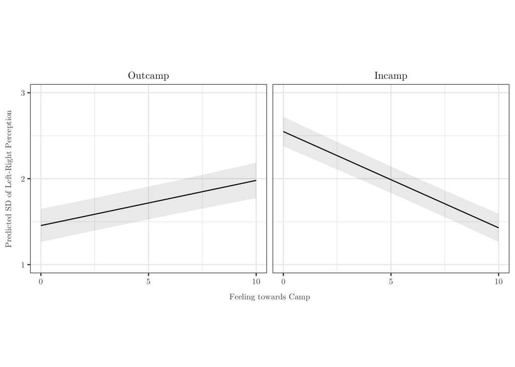

Figure 1: Perceived Camp Variance at Different Levels of Affect

# 6 Discussion

Under the premise that parties in multi-party systems are first, perceived as parts of larger camps, and second, that these camps form the base of political identities, I applied the concept of outgroup homogeneity to the perception of political parties. Given that the affective polarisation literature is, at its core, linked to stereotypical perceptions, I also assumed that this homogeneity perception would be associated with negative affect towards the outcamp. The statistical results do confirm these hypotheses, showing that the outgroup is indeed perceived with less variance than both, the own ingroup and the outgroup’s self-perception, and that the perceived variance decreases with increasingly negative feelings towards the outgroup.

This gives reason to investigate this phenomenon further. The perception of homogeneity or lack of differentiation between political opponents could be an important building block in explaining affective polarisation. Reduced variance may imply attributing characteristics to opponents that they themselves may not perceive, equating them with, or bringing them closer to, their more extreme group members. Differences of opinion are not seen between oneself and outgroup members, but with the group as a whole, making political coalitions and exchanges more difficult. In this way, outgroup homogeneity could enable a *polarisation feedback loop* (Wilson et al., 2020) in which negative impressions are inferred to the whole outgroup, increasing perceived polarisation and negativity towards that group and leading to actual polarisation.

More specifically, the first results here could also be an important piece in explaining polarisation in multi-party systems. As polarisation does not occur between two clear points, the perception of the opposition parties as a more monolithic block could explain more general negative feelings towards them. Party camps have been theorised, but not really tested. My results are no test for the existence of such camps either, however, the observed homogeneity perception can be taken as indication of dynamics occurring between such camps. Going a step further, the approach used here could even be argued to make for a harder test of the theory. Coding parties into the outgroup that are not universally agreed upon in their camp-affiliation necessarily increases the variance in that camp. Nevertheless, for future revisions of this paper, I aim to apply a suitable statistical approach to confirm these camps or identify different ones.

Future revisions should, furthermore, expand the theoretical and empirical scope of this paper. Looking at other dimensions of polarisation (such as perception on different issue dimensions, perception of outgroup attitudes or perception of overall polarisation) might be interesting to explore further, as would several group context factors that have been shown to influence outgroup homogeneity perceptions (Rubin & Badea, 2012).

Each party system is different. It must therefore be clear that this analysis is a broad first look at the phenomenon. Future research should look more closely at the effect in country-specific contexts to gain a better understanding. Such a more detailed investigation could also include temporal effects. My theory deliberately does not specify a causal direction between negative affect and homogeneity perceptions, but assumes a feedback loop between the two. Analysing panel data could help to uncover this mechanism.

# 7 Conclusion

In this initial analysis, I found that, as theorized, the political outgroup is seen with less differentiation than the ingroup and that this effect is stronger with increasing dislike of the opposition. The results rely on the assumption of just two camps of parties on the two sides of the Left-Right spectrum. Nonetheless, they give reason to further explore this phenomenon and might be a crucial step in understanding processes of affective polarisation in general and in multi-party contexts specifically.

# References

Abeles, A. T., Howe, L. C., Krosnick, J. A., & MacInnis, B. (2019). Perception of public opinion on global warming and the role of opinion deviance. *Journal of Environmental Psychology*, *63*, 118–129. https://doi.org/10.1016/j.jenvp.2019.04.001

Abramowitz, A. I., & Saunders, K. L. (2008). Is Polarization a Myth? *The Journal of Politics*, *70*(2), 542–555. https://doi.org/10.1017/s0022381608080493

Ackerman, J. M., Shapiro, J. R., Neuberg, S. L., Kenrick, D. T., Becker, D. V., Griskevicius, V., Maner, J. K., & Schaller, M. (2006). *They All Look the Same to Me (Unless They’re Angry)*. *17*(10).

Ahler, D. J., & Sood, G. (2018). The Parties in Our Heads: Misperceptions about Party Composition and Their Consequences. *The Journal of Politics*, *80*(3), 964–981. https://doi.org/10.1086/697253

Areal, J. (2022). “Them” without “us”: Negative identities and affective polarization in Brazil. *Political Research Exchange*, *4*(1), 2117635. https://doi.org/10.1080/2474736X.2022.2117635

Bantel, I. (2023). Camps, not just parties. The dynamic foundations of affective polarization in multi-party systems. *Electoral Studies*, *83*, 102614. https://doi.org/10.1016/j.electstud.2023.102614

Bartsch, R. A., Judd, C. M., Louw, D. A., Park, B., & Ryan, C. S. (1997). Cross-National Outgroup Homogeneity: United States and South African Stereotypes. *South African Journal of Psychology*, *27*(3), 166–170. https://doi.org/10.1177/008124639702700306

Béjar, S., Moraes, J. A., & López-Cariboni, S. (2020). Elite polarization and voting turnout in Latin America, 1993–2010. *Journal of Elections, Public Opinion and Parties*, *30*(1), 1–21. https://doi.org/10.1080/17457289.2018.1545775

Berntzen, L. E., Kelsall, H., & Harteveld, E. (2022). *Affective polarization and Its consequences: Avoidance, intolerance and support for violence in the UK and Norway* [Preprint]. Open Science Framework. https://doi.org/10.31219/osf.io/sdm7p

Billig, M., & Tajfel, H. (1973). Social categorization and similarity in intergroup behaviour. *European Journal of Social Psychology*, *3*(1), 27–52. https://doi.org/10.1002/ejsp.2420030103

Boldry, J. G., Gaertner, L., & Quinn, J. (2007). Measuring the Measures: A Meta-Analytic Investigation of the Measures of Outgroup Homogeneity. *Group Processes & Intergroup Relations*, *10*(2), 157–178. https://doi.org/10.1177/1368430207075153

Brewer, M. B. (1993). Social Identity, Distinctiveness, and In-Group Homogeneity. *Social Cognition*, *11*(1), 150–164. https://doi.org/10.1521/soco.1993.11.1.150

Dahlberg, S. (2013). Does context matter The impact of electoral systems, political parties and individual characteristics on voters’ perceptions of party positions. *Electoral Studies*, *32*(4), 670–683. https://doi.org/10.1016/j.electstud.2013.02.003

Dalton, R. J. (2021). Modeling ideological polarization in democratic party systems. *Electoral Studies*, *72*, 102346. https://doi.org/10.1016/j.electstud.2021.102346

Dassonneville, R., & Çakır, S. (2021). Party System Polarization and Electoral Behavior. In *Oxford Research Encyclopedia of Politics*. Oxford University Press. https://doi.org/10.1093/acrefore/9780190228637.013.1979

Druckman, J. N., Klar, S., Krupnikov, Y., Levendusky, M., & Ryan, J. B. (2021). Affective polarization, local contexts and public opinion in America. *Nature Human Behaviour*, *5*(1), 28–38. https://doi.org/10.1038/s41562-020-01012-5

Druckman, J. N., & Levendusky, M. S. (2019). What Do We Measure When We Measure Affective Polarization? *Public Opinion Quarterly*, *83*(1), 114–122. https://doi.org/10.1093/poq/nfz003

Finkel, E. J., Bail, C. A., Cikara, M., Ditto, P. H., Iyengar, S., Klar, S., Mason, L., McGrath, M. C., Nyhan, B., Rand, D. G., Skitka, L. J., Tucker, J. A., Van Bavel, J. J., Wang, C. S., & Druckman, J. N. (2020). Political sectarianism in America. *Science*, *370*(6516), 533–536. https://doi.org/10.1126/science.abe1715

Gidron, N., Adams, J., & Horne, W. (2018). How Ideology, Economics and Institutions Shape Affective Polarization in Democratic Polities. *Annual Conference of the American Political Science Association*.

Guber, D. L. (2013). A Cooling Climate for Change? Party Polarization and the Politics of Global Warming. *American Behavioral Scientist*, *57*(1), 93–115. https://doi.org/10.1177/0002764212463361

Harteveld, E. (2021a). Fragmented foes: Affective polarization in the multiparty context of the Netherlands. *Electoral Studies*, *71*, 102332. https://doi.org/10.1016/j.electstud.2021.102332

Harteveld, E. (2021b). Ticking all the boxes? A comparative study of social sorting and affective polarization. *Electoral Studies*, *72*, 102337. https://doi.org/10.1016/j.electstud.2021.102337

Harteveld, E., & Wagner, M. (2023). Does affective polarisation increase turnout? Evidence from Germany, The Netherlands and Spain. *West European Politics*, *46*(4), 732–759. https://doi.org/10.1080/01402382.2022.2087395

Hobolt, S. B., Leeper, T. J., & Tilley, J. (2021). Divided by the Vote: Affective Polarization in the Wake of the Brexit Referendum. *British Journal of Political Science*, *51*(4), 1476–1493. https://doi.org/10.1017/S0007123420000125

Hornsey, M. J. (2008). Social Identity Theory and Self-categorization Theory: A Historical Review. *Social and Personality Psychology Compass*, *2*(1), 204–222. https://doi.org/10.1111/j.1751-9004.2007.00066.x

Huddy, L., Bankert, A., & Davies, C. (2018). Expressive Versus Instrumental Partisanship in Multiparty European Systems: Expressive vs. Instrumental Partisanship. *Political Psychology*, *39*, 173–199. https://doi.org/10.1111/pops.12482

Imre, M. (2023). Intra-party heterogeneity and voter perceptions of party positions. *Electoral Studies*, *83*, 102623. https://doi.org/10.1016/j.electstud.2023.102623

Iyengar, S., Lelkes, Y., Levendusky, M., Malhotra, N., & Westwood, S. J. (2019). The Origins and Consequences of Affective Polarization in the United States. *Annual Review of Political Science*, *22*(1), 129–146. https://doi.org/10.1146/annurev-polisci-051117-073034

Iyengar, S., Sood, G., & Lelkes, Y. (2012). Affect, Not Ideology. *Public Opinion Quarterly*, *76*(3), 405–431. https://doi.org/10.1093/poq/nfs038

Iyengar, S., & Westwood, S. J. (2015). Fear and Loathing across Party Lines: New Evidence on Group Polarization. *American Journal of Political Science*, *59*(3), 690–707. https://doi.org/10.1111/ajps.12152

Kelly, C. (1989). Political identity and perceived intragroup homogeneity. *British Journal of Social Psychology*, *28*(3), 239–250. https://doi.org/10.1111/j.2044-8309.1989.tb00866.x

Krosnick, J. A., & Brannon, L. A. (1993). The Impact of the Gulf War on the Ingredients of Presidential Evaluations: Multidimensional Effects of Political Involvement. *American Political Science Review*, *87*(4), 963–975. https://doi.org/10.2307/2938828

Mason, L. (2016). A Cross-Cutting Calm: How Social Sorting Drives Affective Polarization. *Public Opinion Quarterly*, *80*(S1), 351–377. https://doi.org/10.1093/poq/nfw001

Ostrom, T. M., & Sedikides, C. (1992). Out-group homogeneity effects in natural and minimal groups. *Psychological Bulletin*, *112*(3), 536–552. https://doi.org/10.1037/0033-2909.112.3.536

Reiljan, A. (2020). “Fear and loathing across party lines” (also) in Europe: Affective polarisation in European party systems. *European Journal of Political Research*, *59*(2), 376–396. https://doi.org/10.1111/1475-6765.12351

Rubin, M., & Badea, C. (2007). Why Do People Perceive Ingroup Homogeneity on Ingroup Traits and Outgroup Homogeneity on Outgroup Traits? *Personality and Social Psychology Bulletin*, *33*(1), 31–42. https://doi.org/10.1177/0146167206293190

Rubin, M., & Badea, C. (2012). They’re All the Same!. . . But for Several Different Reasons: A Review of the Multicausal Nature of Perceived Group Variability. *Current Directions in Psychological Science*, *21*(6), 367–372. https://doi.org/10.1177/0963721412457363

Sartori, G. (2005). *Parties and party systems: A framework for analysis*. ECPR.

The Comparative Study Of Electoral Systems. (2020). *CSES Module 5 Advanced Release 2*. CSES - Comparative Study of Electoral Systems. https://doi.org/10.7804/CSES.MODULE5.2020-05-14

Törnberg, P. (2022). How digital media drive affective polarization through partisan sorting. *Proceedings of the National Academy of Sciences*, *119*(42), e2207159119. https://doi.org/10.1073/pnas.2207159119

Wagner, M. (2021). Affective polarization in multiparty systems. *Electoral Studies*, *69*, 102199. https://doi.org/10.1016/j.electstud.2020.102199

Wagner, M., & Eberl, J.-M. (2022). *Divided by the Jab: On the Nature, Origins, and Consequences of COVID-19 Vaccination Identities* [Preprint]. Open Science Framework. https://doi.org/10.31219/osf.io/zcas8

Wessels, B., & Schmitt, H. (2008). Meaningful choices, political supply, and institutional effectiveness. *Electoral Studies*, *27*(1), 19–30. https://doi.org/10.1016/j.electstud.2007.11.010

Wilson, A. E., Parker, V. A., & Feinberg, M. (2020). Polarization in the contemporary political and media landscape. *Current Opinion in Behavioral Sciences*, *34*, 223–228. https://doi.org/10.1016/j.cobeha.2020.07.005

# Appendix

Table 3: Variance in Left-Right Perception

| Mean of Standard Deviation Country | Mean of Standard Deviation Incamp1 | Mean of Standard Deviation Outcamp1 | Mean of Standard Deviation p-value2 |
| --- | --- | --- | --- |
| Full Sample | 1.89 (0.95) N(9,599) | 1.68 (0.93) N(9,531) | <0.001*** |
| Austria | 1.37 (0.57) N(732) | 1.29 (0.72) N(733) | <0.001*** |
| Denmark | 1.89 (0.77) N(864) | 1.71 (0.65) N(858) | <0.001*** |
| Germany | 1.98 (0.74) N(997) | 1.90 (0.64) N(999) | 0.052 |
| Italy | 2.09 (2.01) N(743) | 1.70 (2.18) N(700) | <0.001*** |
| Netherlands | 2.03 (0.97) N(1,133) | 1.78 (1.00) N(1,120) | <0.001*** |
| Norway | 2.14 (0.83) N(1,454) | 1.98 (0.78) N(1,455) | <0.001*** |
| Portugal | 1.78 (0.94) N(436) | 1.01 (1.05) N(429) | <0.001*** |
| Sweden | 1.77 (0.62) N(2,824) | 1.63 (0.58) N(2,823) | <0.001*** |
| United Kingdom | 1.98 (2.32) N(416) | 1.49 (1.88) N(414) | <0.001*** |

1Mean (Variance)  
2*p<0.05; **p<0.01; ***p<0.001

Table 4: Group Affect

| Mean of Feeling towards Camp Country | Mean of Feeling towards Camp Incamp1 | Mean of Feeling towards Camp Outcamp1 | Mean of Feeling towards Camp p-value2 |
| --- | --- | --- | --- |
| Full Sample | 5.84 (2.32) N(10,033) | 3.01 (3.41) N(9,958) | <0.001*** |
| Austria | 5.93 (1.30) N(745) | 2.82 (1.76) N(745) | <0.001*** |
| Denmark | 6.07 (2.31) N(944) | 2.58 (2.16) N(932) | <0.001*** |
| Germany | 6.35 (1.88) N(1,044) | 4.29 (3.75) N(1,041) | <0.001*** |
| Italy | 5.30 (3.38) N(771) | 2.22 (3.71) N(767) | <0.001*** |
| Netherlands | 5.96 (1.84) N(1,165) | 4.80 (2.57) N(1,160) | <0.001*** |
| Norway | 5.51 (1.65) N(1,456) | 2.93 (1.89) N(1,456) | <0.001*** |
| Portugal | 5.77 (2.35) N(466) | 2.77 (3.85) N(466) | <0.001*** |
| Sweden | 5.82 (2.59) N(2,960) | 2.48 (2.50) N(2,909) | <0.001*** |
| United Kingdom | 5.97 (3.27) N(482) | 1.90 (3.12) N(482) | <0.001*** |

1Mean (Variance)  
2*p<0.05; **p<0.01; ***p<0.001

Table 5: Random Effects by Country

| Country | Intercept | SD |
| --- | --- | --- |
| Austria | -0.314 | 0.034 |
| Denmark | 0.114 | 0.032 |
| Germany | 0.208 | 0.029 |
| Italy | 0.136 | 0.035 |
| Netherlands | 0.067 | 0.028 |
| Norway | 0.377 | 0.024 |
| Portugal | -0.572 | 0.044 |
| Sweden | 0.049 | 0.018 |
| United Kingdom | -0.064 | 0.045 |

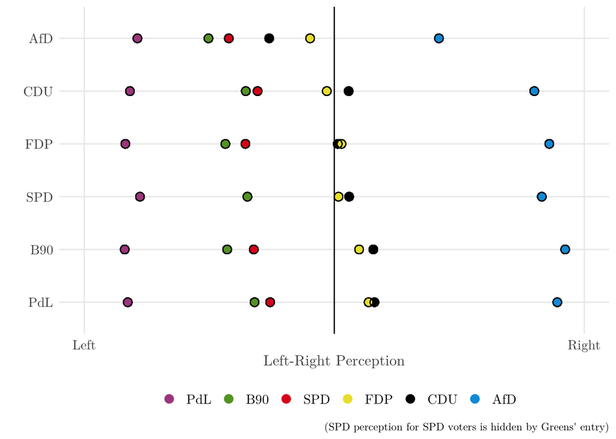

Figure 2: Mean Party Perceptions by Voter Group in Germany

## Footnotes

[^1]: “Even more egregiously, they estimated that 38.2% of Republicans earned over $250,000 per year when just 2.2% of GOP supporters do” (Ahler & Sood, 2018, p. 3)
[^2]: Traits include, for example, personality traits (“ambitious, imaginative, arrogant” (Rubin & Badea, 2007, p. 36) or attitudes (“capitalistic, ‘Other = should be like the U.S.’, ‘Apartheid serves a useful purpose’”, (Bartsch et al., 1997, p. 167)
[^3]: Austria, Denmark, Germany, Italy, Netherlands, Norway, Portugal, Sweden, United Kingdom
[^4]: Three notable countries are missing: France, Spain and Belgium. Unfortunately, the French CSES 5 data only features Left-Right perception items for “Republicans” and “Parti Socialiste”, which makes the analysis impossible. Spain is not featured in the data at all and Belgium, although a very interesting and theoretically challenging case, was disregarded for this first look because of coding issues due to its more complex party structure.
[^5]: Mean like scores for the camps can be found in Table 4